# Variance OLS coeffs

### **NOTES ON STATISTICS, PROBABILITY and MATHEMATICS**

### Variance of Estimated Regression Coefficients:

Proof that the [variance of the estimated coefficients](https://stats.stackexchange.com/a/358847/67822) $\hat \beta = \sigma^2 \left(X^\top X \right)^{-1}$ where the estimation of $\sigma$ depends on the number of estimated parameters, $p,$ and the number of observations, $n$: $\text{SSE} = e^\top e$ has $\text{df}_E = n − p.$ The estimate for $\sigma^2$ is

$$s^2 = \frac{\mathrm e^\top \mathrm
e}{n-p}= \frac{(\mathrm Y − \mathrm{Xb})^\top(\mathrm Y −
\mathrm{Xb})}{n-p}= \frac{\text{SSE}}
{\text{df}_E}= \text{MSE}$$

$$s = \sqrt{s^2}= \text{Root
MSE}$$

From [this video](https://youtu.be/jyBtfhQsf44?list=PLVhS9-aIl4U-Guw_wvCHMhF2unUGVyWEu) and [this post](http://math.stackexchange.com/a/687361/152225):

We know that $\hat \beta= \left(X^\top X \right)^{-1} X^\top Y.$

And we want to calcualte the variance of the parameter estimate:

$\begin{align}\text{var}\left(\hat \beta\right) &= \text{var}\left[\left(X^\top X \right)^{-1} X^\top y\right]\\\quad &\underset{\text{var}(Ay)=A\,\text{var}(y)\,A^\top}{=}\quad\left[\left(X^\top X \right)^{-1} X^\top \right] \color{blue}{\text{var}(y)} \left[\left(X^\top X \right)^{-1} X^\top \right]^\top\\ &\underset{*}=\quad\left[\left(X^\top X \right)^{-1} X^\top \right] {\bf I}\sigma^2 \left[\left(X^\top X \right)^{-1} X^\top \right]^\top\\ &=\sigma^2\left[\left(X^\top X \right)^{-1} X^\top \right]\left[\left(X^\top X \right)^{-1} X^\top \right]^\top\\ &\quad\underset{(AB)^\top = B^\top A^\top}{=}\quad\sigma^2\left[\left(X^\top X \right)^{-1} X^\top \right]\left[\left(X^\top\right)^\top \left(\left(X^\top X \right)^{-1}\right)^\top \right]\\ &\quad\underset{(A^{-1})^\top = (A^\top)^{-1}}{=}\quad\sigma^2\left[\left(X^\top X \right)^{-1} X^\top \right]\left[X \left(\left(X^\top X \right)^\top\right)^{-1} \right]\\ &\quad\underset{A^\top A \text{ is symmetrical}}{=}\quad\sigma^2\left[\left(X^\top X \right)^{-1} X^\top \right]\left[X \left(X^\top X \right)^{-1} \right]\\ &\quad\underset{ \text{regrouping}}{=}\quad\sigma^2\left[\left(X^\top X \right)^{-1}\right] X^\top X \left[\left(X^\top X \right)^{-1} \right]\\ &=\bbox[yellow, 2px]{\sigma^2 \left(X^\top X\right)^{-1}} \end{align}$

$*$ because:

$$\text{var}(y)=
\text{var}\left(X\beta+\varepsilon\right)$$

and since $X\beta$ is fixed, $\text{var}(y)= \text{var}\left(X\beta+\varepsilon\right)=0+\text{var}(\epsilon\vert X)=\sigma^2 \bf I$, since $\varepsilon \sim N(0, \sigma^2 \bf I).$

This latter part comes from the [Gauss-Markov sphericity of errors](https://en.wikipedia.org/wiki/Gauss–Markov_theorem#Spherical_errors) assumption:

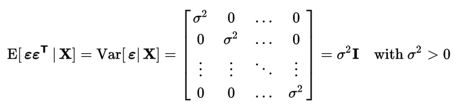

In the case of a single regressor (and intercept) $Y = \beta_0 + \beta_1 x$, again, with the assumption that $Y \sim N(\mu = \beta_0 + \beta_1 x, \sigma^2):$

$$\operatorname{var}(\hat
\beta):=\sigma^2(\hat \beta)=\begin{bmatrix}\operatorname{var}(\hat
\beta_0) &\operatorname{cov}(\hat \beta_0, \hat
\beta_1)\\\operatorname{cov}(\hat \beta_0, \hat \beta_1)&
\operatorname{var}(\hat \beta_1)\end{bmatrix}$$

and having derived $\operatorname{var}(\hat \beta) =\sigma^2 \left(X^\top X\right)^{-1},$ and [knowing that](http://rinterested.github.io/statistics/OLS_linear_algebra.html)

$$\left(X^\top
X\right)^{-1}=\begin{bmatrix}\frac{\sum x_i^2}{n\sum(x_i - \bar x)^2}
& \frac{-\sum x_i}{n\sum(x_i - \bar x)^2}\\\frac{-\sum
x_i}{n\sum(x_i - \bar x)^2}& \frac{1}{\sum(x_i - \bar
x)^2}\end{bmatrix}$$

$$\operatorname{var}(\hat \beta) =\sigma^2
\left(X^\top X\right)^{-1}=\begin{bmatrix}\frac{\sigma^2\sum
x_i^2}{n\sum(x_i - \bar x)^2} & \frac{-\sigma^2\sum x_i}{n\sum(x_i -
\bar x)^2}\\\frac{-\sigma^2\sum x_i}{n\sum(x_i - \bar x)^2}&
\frac{\sigma^2}{\sum(x_i - \bar x)^2}\end{bmatrix}$$

This is my attempt at answer [this question](http://stats.stackexchange.com/q/193229/67822).

The question is what happens to the **variance** of a parameter estimates ($\hat \beta_i$) with the introduction of a new [*control variable*](https://www.quora.com/What-are-control-variables-and-how-do-I-use-them-in-regression-analysis) in a regression model? And secondarily, how would the statistical testing of $\hat \beta_i$ be affected?

The answer is that **the variance of the estimated parameter will increase**; and **the $p$-value will increase**.

Your question revolves around the problem with [overfitting](https://en.wikipedia.org/wiki/Overfitting) and the [bias-variance trade-off](https://en.wikipedia.org/wiki/Bias–variance_tradeoff).

The more regressors you add, the lower the $\text{RSS}$ (residual sum of squares) and the higher the $R^2$. In fact, if you just add columns of pure noise (`rnorm()`) to your data, and you run OLS regressions after every addition, you will see a marked, monotonic decrease in the $\text{RSS}$. I tested this with [an example](https://github.com/RInterested/SIMULATIONS_and_PROOFS/blob/master/R%20squared%20lower%20more%20regressors):

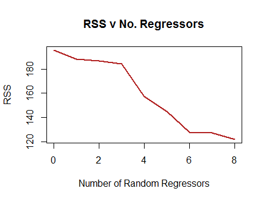

The idea is that in OLS the hat matrix $X (X^TX)^{-1}X^T$ is a projection matrix of the vector of observed $y$ values onto the column space of the model matrix. The higher the dimensions of the column space (the more vectors to form a basis), the closer $\hat y$ will be to $y$. But at a price!

The estimation of the variance of $\hat \beta_i$ is given by:

$Var[\hat\beta_i]= \sigma^2(X^TX)^{-1}$ with $\sigma^2$ corresponding to the variation of the observations around the predicted values, ($Var[\epsilon|X] = \sigma^2I_n$). The estimation of $\sigma^2$ from the sample is $s^2=\frac{e^Te}{n-p}$ or $\text{MSE}$ (mean squared error). The denominator is the number of observations, $n$ minus the number of parameters, $p$, counting the intercept. It is also referred to as the *error or residual degrees of freedom* ($\small\text{no. observations−no. indepen't variables−1}$). Alternatively, the formula for the $\sigma^2$ estimation, can be expressed as $\text{MSE = RSS/df}$ with $\text{RSS}$ being the same as $\text{SSE}$ (sum of squared errors), $\sum_1^n(y_i - \hat y)^2$.

Therefore the estimation of the variance of the parameter $\hat\beta_i$ is $s^2(X^TX)^{-1}$ or $\text{MSE}\times(X^TX)^{-1}$.

And I think this may be a source of confusion - just because adding another regressor decreases the $\text{MSE}$ by decreasing the $\text{RSS}$ - if it actually does at all, because of the change in the degrees of freedom in the denominator, it can’t be said that the variance for the estimated parameter decreases.

In a parallel OLS simulation ([here](https://github.com/RInterested/SIMULATIONS_and_PROOFS/blob/master/VARIANCE%20OLS%20NO.%20OF%20REGRESSORS)), I found, quite anecdotally, a $\small 3.5\%$ increase in $\text{MSE}$ when adding an extra regressor, with a minimal decrease in $\text{RSS}$.

What controlled the increased variance for the estimate of $\hat\beta_i$ turned out to be the entry for $\hat\beta_i$ in the matrix of cofactors involved in the calculation of the inverse of $(X^TX)^{-1}$, explaining a variance for the estimate of the parameter $\hat\beta_i$ $2.8$ times higher in the presence of the control variable.

An alternative formula for the variance not applicable to the intercept is:

$\large \text{var}[\hat\beta_i]= \frac{\sigma^2}{n \times var[X_i]\times(1\,-\,R_i^2)}$. The key here is that $R_i^2$ is the $R$-square of the regression of the corresponding variable for the parameter $\hat\beta_i$, or $X_i$ against all the other regressors. Therefore, the better the regression model of $X_i \sim \text{control variable}$, the higher the estimated $\text{var}[\hat\beta_i].$

Naturally, the higher the variance (or squared error), the broader the confidence intervals, and the lower the $t$ statistic, resulting in a higher $p$-value.

[Home Page](http://rinterested.github.io/statistics/index.html)

**NOTE: These are tentative notes on different topics for personal use - expect mistakes and misunderstandings.**